# Visualization Graphs

Jingjing_Tang

11/27/2017

BST 260 Final Project Group: Chuying Ma, Jingjing Tang, Jie Yin, Xuewei Zhang

This Rmd file is for data analysis and visualization.

```r
library(maps)
library(ggplot2)
library("SASxport")
library(ggmap)
library(mapdata)
library(RColorBrewer)
library(gganimate)
library(dplyr)
dat <- read.csv("data_3_expo.csv")
dat051<- read.csv("state_05.csv") %>% select(-full, -X)
dat061<- read.csv("state_06.csv") %>% select(-full, -X)
dat071<- read.csv("state_07.csv") %>% select(-full, -X)
dat081<- read.csv("2008_data_state.csv")
dat091<- read.csv("2009_data_state.csv")
dat101<- read.csv("2010_data_state.csv")
dat_state_05_10 <- rbind (dat051, dat061, dat071, dat081,dat091,dat101)
```

Our rough guesses according to the spatial distributions is confirmed by the correlation information among diseases.

Mental status and heart diseases are strongly related while the correlations between asthma and other disease are very small.

Based on this analysis, we use the information of heart attack to represent the three types of heart diseases.

# correlation among diseases

```r
library(GGally)
# Check correlation between variables
cor(dat_state_05_10[3:7])
```

```
##              menthlth heartattack ACheartdis     stroke     asthma
## menthlth    1.0000000   0.6869433  0.7501571 0.61656578 0.12602136
## heartattack 0.6869433   1.0000000  0.8794049 0.82439963 0.10631331
## ACheartdis  0.7501571   0.8794049  1.0000000 0.64360834 0.20519383
## stroke      0.6165658   0.8243996  0.6436083 1.00000000 0.03456442
## asthma      0.1260214   0.1063133  0.2051938 0.03456442 1.00000000
```

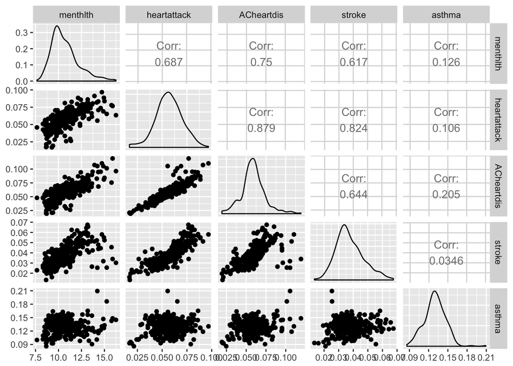

```r
# Check correlations (as scatterplots), distribution and print corrleation coefficient
ggpairs(dat_state_05_10[3:7])
```

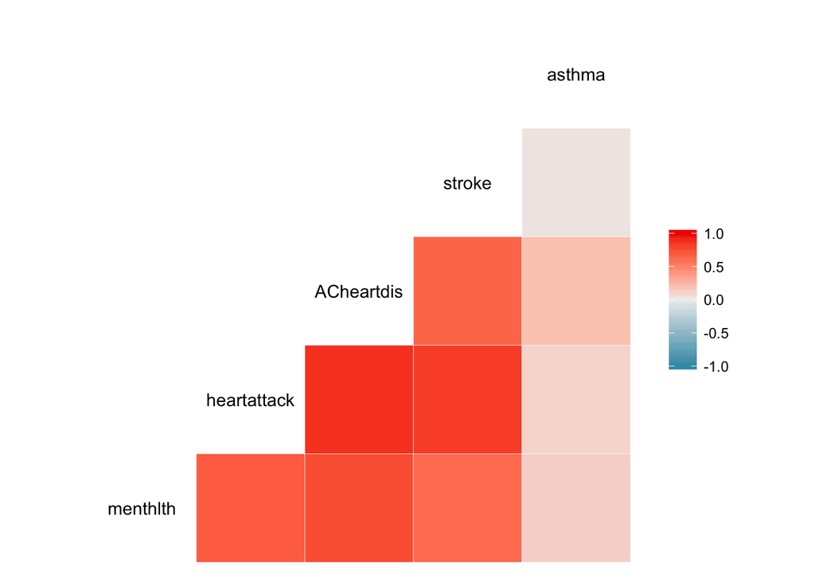

```r
# Nice visualization of correlations
ggcorr(dat_state_05_10[3:7], method = c("everything", "pearson"))
```

# expo VS income/race/edu

```r
library(tidyverse)
dat_raw08 <- read.csv("2008_data_raw.csv") %>% mutate(race = ORACE2, educ = EDUCA, income = INCOME2, menthlth = MENTHLTH, heartattack = CVDINFR4, ACheartdis = CVDCRHD4, stroke = CVDSTRK3, asthma = ASTHMA2) %>%
  select(race, educ, income, menthlth, heartattack, ACheartdis, stroke, asthma)
dat_raw09 <- read.csv("2009_data_raw.csv") %>% mutate(race = ORACE2, educ = EDUCA, income = INCOME2, menthlth = MENTHLTH, heartattack = CVDINFR4, ACheartdis = CVDCRHD4, stroke = CVDSTRK3, asthma = ASTHMA2) %>%
  select(race, educ, income, menthlth, heartattack, ACheartdis, stroke, asthma)
dat_raw010 <- read.csv("2010_data_raw.csv") %>% mutate(race = ORACE2, educ = EDUCA, income = INCOME2, menthlth = MENTHLTH, heartattack = CVDINFR4, ACheartdis = CVDCRHD4, stroke = CVDSTRK3, asthma = ASTHMA2) %>%
  select(race, educ, income, menthlth, heartattack, ACheartdis, stroke, asthma)
dat_raw <- rbind(na.omit(dat_raw08), na.omit(dat_raw09), na.omit(dat_raw010)) %>% mutate(group = c(NA))
dat_raw$educ[which(dat_raw$educ == 1 | dat_raw$educ == 2)] <- c("value1")
dat_raw$educ[which(dat_raw$educ == 3 | dat_raw$educ == 4)] <- c("value2")
dat_raw$educ[which(dat_raw$educ == 5 | dat_raw$educ == 6)] <- c("value3")
dat_raw$income[which(dat_raw$income == 1 | dat_raw$income == 2)] <- c("value1")
dat_raw$income[which(dat_raw$income == 3 | dat_raw$income == 4)] <- c("value2")
dat_raw$income[which(dat_raw$income == 5 | dat_raw$income == 6)] <- c("value3")
dat_raw$income[which(dat_raw$income == 7 | dat_raw$income == 8)] <- c("value4")
dat_raw$race[which(dat_raw$race == 1 )] <- c("value1")
dat_raw$race[which(dat_raw$race == 2 )] <- c("value2")
dat_raw$race[which(dat_raw$race == 3 )] <- c("value3")
dat_raw$race[which(dat_raw$race == 4 | dat_raw$race == 5 |dat_raw$race == 6)] <- c("value4")
dat_raw <- dat_raw %>% group_by(income) %>% mutate(income_num = n()) %>% ungroup() %>%
  group_by(educ) %>% mutate(educ_num = n()) %>% ungroup() %>%
  group_by(race) %>% mutate(race_num = n()) %>% ungroup()


dat_raw_menthlth <- dat_raw %>% filter(menthlth > 10) %>% mutate(group = c("A"))
dat_raw_heartattack <- dat_raw %>% filter(heartattack == 1) %>% mutate(group = c("B"))
dat_raw_ACheartdis <- dat_raw %>% filter(ACheartdis == 1) %>% mutate(group = c("C"))
dat_raw_stroke <- dat_raw %>% filter(stroke ==1) %>% mutate(group = c("D"))
dat_raw_asthma <- dat_raw %>% filter(asthma ==1) %>% mutate(group = c("E"))
dat_raw_com <- rbind(dat_raw_menthlth, dat_raw_heartattack, dat_raw_ACheartdis, dat_raw_stroke, dat_raw_asthma)

dat_race <- na.omit(dat_raw_com) %>% select(group, race, race_num) %>% group_by(group, race) %>% summarise(value = n()/unique(race_num)) %>% ungroup() %>%  mutate(individual = c("race"),   observation = race) %>% select(individual, group, observation, value)
dat_educ <- na.omit(dat_raw_com) %>% select(group, educ, educ_num) %>% group_by(group, educ) %>% summarise(value = n()/unique(educ_num)) %>% ungroup() %>% mutate(individual = c("educ"), observation = educ) %>%  select(individual, group, observation, value)
dat_income <- na.omit(dat_raw_com) %>% select(group, income, income_num) %>% group_by(group, income) %>% summarise(value = n()/unique(income_num)) %>% ungroup() %>% mutate(individual = c("income"), observation = income) %>% select(individual, group, observation, value)
data_bar <- rbind.data.frame(dat_race, dat_educ, dat_income) %>% arrange(group, individual, observation)
```

### population_disease

```r
dat_raw_com %>% group_by(group) %>% summarise(population = n()) %>% mutate(groupname = c("bad mental status",  "heart attack", "angina or coronary heart disease", "stroke", "asthma")) %>% select(groupname, population)
```

```
## # A tibble: 5 x 2
##                          groupname population
##                              <chr>      <int>
## 1                bad mental status       4045
## 2                     heart attack        745
## 3 angina or coronary heart disease        759
## 4                           stroke        643
## 5                           asthma       2722
```

Among the interviewed population, the number of people suffering from potential mental illness or asthma is much larger than the number of people with heart diseases.

### bar_plot1

```r
# library
data_bar_heart <- data_bar %>% filter(!group %in%  c("A","E"))

library(tidyverse)
library(viridis)
```

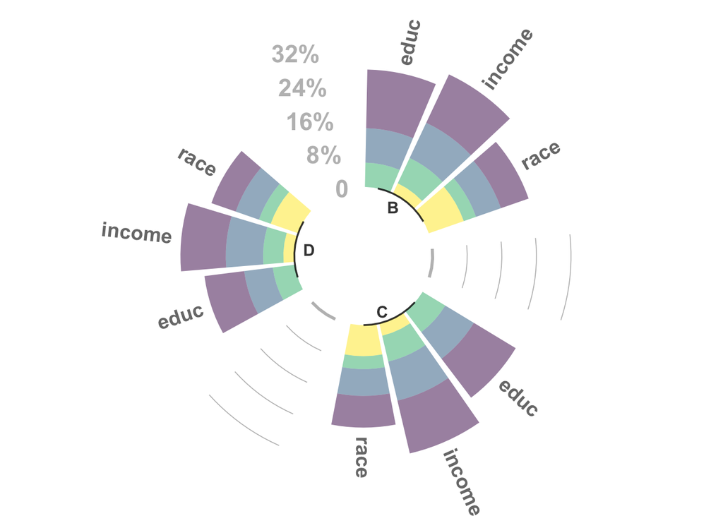

```r
# Set a number of 'empty bar' to add at the end of each group
empty_bar=2
nObsType=nlevels(as.factor(data_bar_heart$observation))
to_add = data.frame( matrix(NA, empty_bar*nlevels(as.factor(data_bar_heart$group))*nObsType, ncol(data_bar_heart)) )
colnames(to_add) = colnames(data_bar_heart)
to_add$group=rep(levels(as.factor(data_bar_heart$group)), each=empty_bar*nObsType )
data_bar_heart=rbind(data_bar_heart, to_add)
data_bar_heart=data_bar_heart%>% arrange(group, individual)
data_bar_heart$id=c(rep( seq(1, 15) , c(rep(c(3,4,4,4,4),3))))

# Get the name and the y position of each label
label_data= data_bar_heart %>% group_by(id, individual) %>% summarize(tot=sum(value))
number_of_bar=nrow(label_data)
angle= 90 - 360 * (label_data$id-0.5) /number_of_bar     # I substract 0.5 because the letter must have the angle of the center of the bars. Not extreme right(1) or extreme left (0)
label_data$hjust<-ifelse( angle < -90, 1, 0)
label_data$angle<-ifelse(angle < -90, angle+180, angle)

# prepare a data frame for base lines
base_data=data_bar_heart %>%
  group_by(group) %>%
  summarize(start=min(id), end=max(id) - empty_bar) %>%
  rowwise() %>%
  mutate(title=mean(c(start, end)))

# prepare a data frame for grid (scales)
grid_data = base_data
grid_data$end = grid_data$end[ c( nrow(grid_data), 1:nrow(grid_data)-1)] + 1
grid_data$start = grid_data$start - 1
grid_data=grid_data[-1,]

# Make the plot
p = ggplot(data_bar_heart) +

  # Add the stacked bar
  geom_bar(aes(x=as.factor(id), y=value, fill=observation), stat="identity", alpha=0.5) +
  scale_fill_viridis(discrete=TRUE) +

  # Add a val=100/200/300/400 lines. I do it at the beginning to make sur barplots are OVER it.
  geom_segment(data=grid_data, aes(x = end, y = 0, xend = start, yend = 0), colour = "grey", alpha=1, size=1 , inherit.aes = FALSE ) +
  geom_segment(data=grid_data, aes(x = end, y = 0.08, xend = start, yend = 0.08), colour = "grey", alpha=1, size=0.3 , inherit.aes = FALSE ) +
  geom_segment(data=grid_data, aes(x = end, y = 0.16, xend = start, yend = 0.16), colour = "grey", alpha=1, size=0.3 , inherit.aes = FALSE ) +
  geom_segment(data=grid_data, aes(x = end, y = 0.24, xend = start, yend = 0.24), colour = "grey", alpha=1, size=0.3 , inherit.aes = FALSE ) +
  geom_segment(data=grid_data, aes(x = end, y = 0.32, xend = start, yend = 0.32), colour = "grey", alpha=1, size=0.3 , inherit.aes = FALSE ) +

  # Add text showing the value of each 100/75/50/25 lines
  annotate("text", x = rep(max(data_bar_heart$id),5), y = c(0, 0.08, 0.16, 0.24, 0.32), label = c("0", "8%", "16%", "24%", "32%") , color="grey", size=6 , angle=0, fontface="bold", hjust=1) +

  ylim(-0.16,max(label_data$tot+0.08, na.rm=T)) +
  theme_minimal() +
  theme(
    legend.position = "none",
    axis.text = element_blank(),
    axis.title = element_blank(),
    panel.grid = element_blank(),
    plot.margin = unit(rep(-1,4), "cm")
  ) +
  coord_polar() +

  # Add labels on top of each bar
  geom_text(data=label_data, aes(x=id, y=tot+0.02, label=individual, hjust=hjust), color="black", fontface="bold",alpha=0.6, size=5, angle= label_data$angle, inherit.aes = FALSE ) +

  # Add base line information
  geom_segment(data=base_data, aes(x = start, y = -0.0001, xend = end, yend = -0.0001), colour = "black", alpha=0.8, size=0.6 , inherit.aes = FALSE )  +
  geom_text(data=base_data, aes(x = title, y = -0.02, label=group), hjust=c(1,1,0), colour = "black", alpha=0.8, size=4, fontface="bold", inherit.aes = FALSE)
p
```